# APG analysis

Analysis walkthrough for “Tuning in to non-adjacencies: Exposure to learnable patterns supports discovering otherwise difficult structures” (Zettersten, Potter & Saffran).

For details on the rationale for individual analyses, see the corresponding paper.

## Experiment 1

### Test Accuracy

#### Accuracy Plot

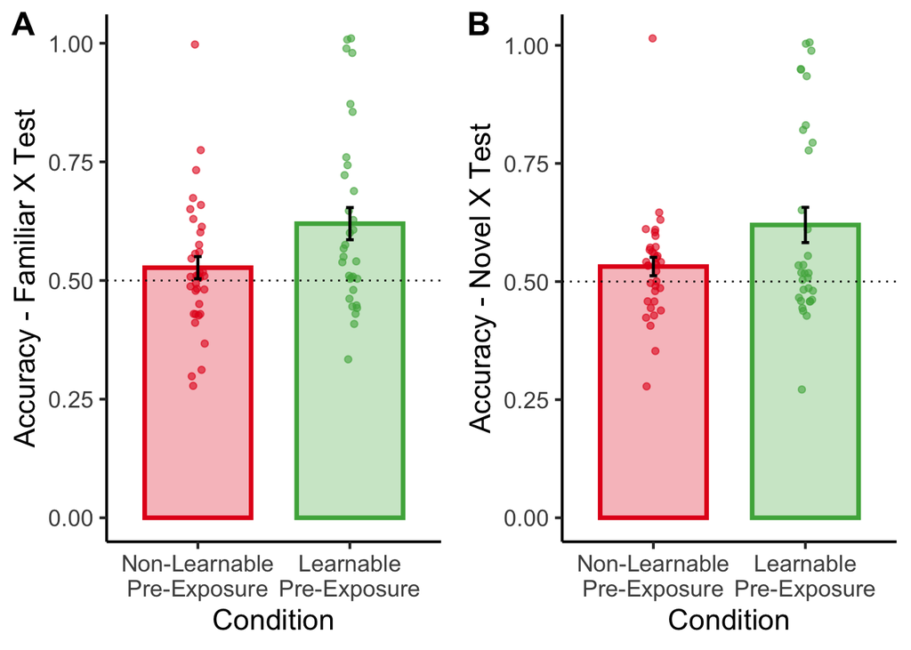

```r
#Familiar X Test
p1 <- ggplot(subset(test_type_exp,testType=="familiarX"&exp=="exp1"),aes(condition,accuracy,fill=condition, color=condition))+
  geom_bar(position=position_dodge(.9), stat="identity", size=1.2,alpha=0.3, width=0.7)+
  geom_jitter(data=subset(subj_testType,testType=="familiarX"&exp=="exp1"),aes(y=acc), width = 0.05, alpha=0.6,shape=21)+
  geom_errorbar(aes(ymin=accuracy-se,ymax=accuracy+se),color="black",position=position_dodge(.9),width=0.05, size=0.8)+
  theme_classic(base_size=16)+
  geom_hline(yintercept=0.5, linetype="dotted")+
  scale_x_discrete(name="Condition",
                   breaks=c("Non-Learnable Pre-Exposure","Learnable Pre-Exposure"),
                   labels=c("Non-Learnable\nPre-Exposure","Learnable\nPre-Exposure"),
                   limits=c("Non-Learnable Pre-Exposure","Learnable Pre-Exposure"))+
  scale_fill_manual(values=c("#4DAF4A","#E41A1C"))+
  scale_color_manual(values=c("#4DAF4A","#E41A1C"))+
  theme(legend.position="none")+
  ylab("Accuracy - Familiar X Test")+
  xlab("Condition")

#Novel X
p2 <- ggplot(subset(test_type_exp,testType=="novelX"&exp=="exp1"),aes(condition,accuracy,fill=condition,color=condition))+
  geom_bar(position=position_dodge(.9), stat="identity", size=1.2,alpha=0.3, width=0.7)+
  geom_jitter(data=subset(subj_testType,testType=="novelX"&exp=="exp1"),aes(y=acc), width = 0.05, alpha=0.6,shape=21)+
  geom_errorbar(aes(ymin=accuracy-se,ymax=accuracy+se),color="black",position=position_dodge(.9),width=0.05, size=0.8)+
  theme_classic(base_size=16)+
  geom_hline(yintercept=0.5, linetype="dotted")+
  scale_x_discrete(name="Condition",
                   breaks=c("Non-Learnable Pre-Exposure","Learnable Pre-Exposure"),
                   labels=c("Non-Learnable\nPre-Exposure","Learnable\nPre-Exposure"),
                   limits=c("Non-Learnable Pre-Exposure","Learnable Pre-Exposure"))+
  scale_fill_manual(values=c("#4DAF4A","#E41A1C"))+
  scale_color_manual(values=c("#4DAF4A","#E41A1C"))+
  theme(legend.position="none")+
  ylab("Accuracy - Novel X Test")+
  xlab("Condition")
plot_grid(p1,p2, labels=c("A","B"),label_size=18)
```

#### Overall Accuracy Table

```r
overall_exp %>%
  filter(exp=="exp1") %>%
  select(-c(se, accuracy_ci,d_prime_ci,c_bias_ci)) %>%
  formattable()
```

| exp | condition | N | accuracy | accuracy_lower_ci | accuracy_upper_ci | d_prime | d_prime_lower_ci | d_prime_upper_ci | c_bias | c_bias_lower_ci | c_bias_upper_ci |
| --- | --- | --- | --- | --- | --- | --- | --- | --- | --- | --- | --- |
| exp1 | Learnable Pre-Exposure | 32 | 0.6197917 | 0.5503856 | 0.6891977 | 0.8180681 | 0.33183941 | 1.3042967 | -0.1721116 | -0.2965946 | -0.0476286 |
| exp1 | Non-Learnable Pre-Exposure | 35 | 0.5293651 | 0.4935915 | 0.5651386 | 0.2026126 | -0.04537869 | 0.4506038 | -0.3028788 | -0.4757694 | -0.1299883 |

#### Accuracy Table By Test Type

```r
test_type_exp %>%
  filter(exp=="exp1") %>%
  select(-c(se, accuracy_ci,d_prime_ci,c_bias_ci)) %>%
  formattable()
```

| exp | condition | testType | N | accuracy | accuracy_lower_ci | accuracy_upper_ci | d_prime | d_prime_lower_ci | d_prime_upper_ci | c_bias | c_bias_lower_ci | c_bias_upper_ci |
| --- | --- | --- | --- | --- | --- | --- | --- | --- | --- | --- | --- | --- |
| exp1 | Learnable Pre-Exposure | familiarX | 32 | 0.6197917 | 0.5505723 | 0.6890110 | 0.7511226 | 0.32051674 | 1.1817285 | -0.24820588 | -0.4281889 | -0.06822284 |
| exp1 | Learnable Pre-Exposure | novelX | 32 | 0.6197917 | 0.5436288 | 0.6959545 | 0.7517021 | 0.28191789 | 1.2214863 | -0.08924026 | -0.2107732 | 0.03229271 |
| exp1 | Non-Learnable Pre-Exposure | familiarX | 35 | 0.5269841 | 0.4794718 | 0.5744965 | 0.1608595 | -0.12636554 | 0.4480845 | -0.47197810 | -0.6295813 | -0.31437490 |
| exp1 | Non-Learnable Pre-Exposure | novelX | 35 | 0.5317460 | 0.4921224 | 0.5713697 | 0.1901106 | -0.04401717 | 0.4242384 | -0.11014830 | -0.3209422 | 0.10064563 |

#### Correlation

##### Correlation between Familiar X and Novel X Trials: Learnable Pre-Exposure

```r
##Correlations between Familiar X and Novel X
c <- corr.test(subset(subj_accuracy_wide, condition=="Learnable Pre-Exposure" & exp=="exp1")[,c("novelX","familiarX")])
c
```

```
## Call:corr.test(x = subset(subj_accuracy_wide, condition == "Learnable Pre-Exposure" &
##     exp == "exp1")[, c("novelX", "familiarX")])
## Correlation matrix
##           novelX familiarX
## novelX      1.00      0.82
## familiarX   0.82      1.00
## Sample Size
## [1] 32
## Probability values (Entries above the diagonal are adjusted for multiple tests.)
##           novelX familiarX
## novelX         0         0
## familiarX      0         0
##
##  To see confidence intervals of the correlations, print with the short=FALSE option
```

```r
c$p
```

```
##                 novelX    familiarX
## novelX    0.000000e+00 7.454645e-09
## familiarX 7.454645e-09 0.000000e+00
```

##### Correlation between Familiar X and Novel X Trials: Non-Learnable Pre-Exposure

```r
c <- corr.test(subset(subj_accuracy_wide, condition=="Non-Learnable Pre-Exposure" & exp=="exp1")[,c("novelX","familiarX")])
c
```

```
## Call:corr.test(x = subset(subj_accuracy_wide, condition == "Non-Learnable Pre-Exposure" &
##     exp == "exp1")[, c("novelX", "familiarX")])
## Correlation matrix
##           novelX familiarX
## novelX      1.00      0.34
## familiarX   0.34      1.00
## Sample Size
## [1] 35
## Probability values (Entries above the diagonal are adjusted for multiple tests.)
##           novelX familiarX
## novelX      0.00      0.04
## familiarX   0.04      0.00
##
##  To see confidence intervals of the correlations, print with the short=FALSE option
```

```r
c$p
```

```
##               novelX  familiarX
## novelX    0.00000000 0.04366703
## familiarX 0.04366703 0.00000000
```

Compute correlation without outlier participant with perfect Familiar X and Novel X accuracy

```r
#check outlier in Non-Learnable Pre-Exposure Condition
outlierTest(lm(novelX~familiarX,subset(subj_accuracy_wide,exp=="exp1"&condition=="Non-Learnable Pre-Exposure")))
```

```
##    rstudent unadjusted p-value Bonferroni p
## 34 5.040898         1.7644e-05   0.00061755
```

```r
#correlation without outlier
c <- corr.test(subset(subj_accuracy_wide, condition=="Non-Learnable Pre-Exposure" & exp=="exp1"&participantCode!="apg_exp1_p7")[,c("novelX","familiarX")])
c
```

```
## Call:corr.test(x = subset(subj_accuracy_wide, condition == "Non-Learnable Pre-Exposure" &
##     exp == "exp1" & participantCode != "apg_exp1_p7")[, c("novelX",
##     "familiarX")])
## Correlation matrix
##           novelX familiarX
## novelX      1.00     -0.14
## familiarX  -0.14      1.00
## Sample Size
## [1] 34
## Probability values (Entries above the diagonal are adjusted for multiple tests.)
##           novelX familiarX
## novelX      0.00      0.44
## familiarX   0.44      0.00
##
##  To see confidence intervals of the correlations, print with the short=FALSE option
```

```r
c$p
```

```
##              novelX familiarX
## novelX    0.0000000 0.4434494
## familiarX 0.4434494 0.0000000
```

##### Interaction between Test Type and Condition

```r
m <- lm(novelX~familiarX*condition, subset(subj_accuracy_wide,exp=="exp1"))
summary(m)
```

```
##
## Call:
## lm(formula = novelX ~ familiarX * condition, data = subset(subj_accuracy_wide,
##     exp == "exp1"))
##
## Residuals:
##      Min       1Q   Median       3Q      Max
## -0.26809 -0.06266 -0.01132  0.04742  0.33776
##
## Coefficients:
##                                               Estimate Std. Error t value
## (Intercept)                                    0.05859    0.07023   0.834
## familiarX                                      0.90546    0.10839   8.354
## conditionNon-Learnable Pre-Exposure            0.32240    0.10511   3.067
## familiarX:conditionNon-Learnable Pre-Exposure -0.61940    0.17996  -3.442
##                                               Pr(>|t|)
## (Intercept)                                    0.40727
## familiarX                                      8.6e-12 ***
## conditionNon-Learnable Pre-Exposure            0.00318 **
## familiarX:conditionNon-Learnable Pre-Exposure  0.00103 **
## ---
## Signif. codes:  0 '***' 0.001 '**' 0.01 '*' 0.05 '.' 0.1 ' ' 1
##
## Residual standard error: 0.1159 on 63 degrees of freedom
## Multiple R-squared:  0.5697, Adjusted R-squared:  0.5492
## F-statistic:  27.8 on 3 and 63 DF,  p-value: 1.425e-11
```

#### Correlation Plot

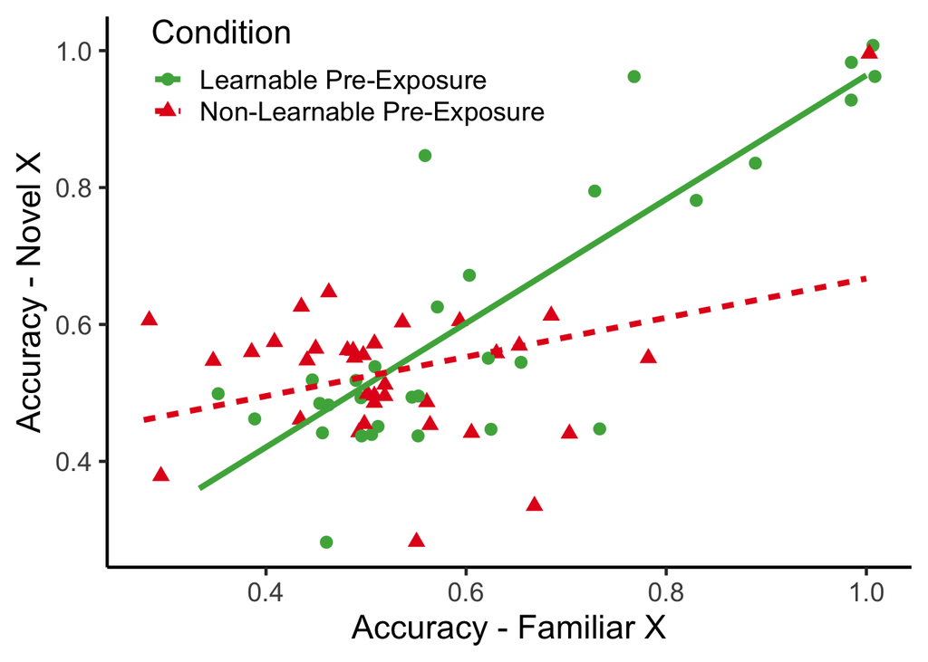

```r
ggplot(subset(subj_accuracy_wide,exp=="exp1"),aes(familiarX,novelX, color=condition,linetype=condition,shape=condition))+
  geom_jitter(width=0.02,height=0.02,size=3)+
  geom_smooth(method=lm,se =F,size=1.5)+
  scale_color_manual(name="Condition",values=c("#4DAF4A","#E41A1C"))+
  scale_linetype_discrete(name="Condition")+
  scale_shape_discrete(name="Condition")+
  ylab("Accuracy - Novel X")+
  xlab("Accuracy - Familiar X")+
  theme_classic(base_size=18)+
  theme(legend.position=c(0.3,0.9))
```

### Logistic Mixed-Effects Model

#### Overall

##### Final Converging Model

The final model with the maximal random effects structure that still allowed the model to converge, as reported in the manuscript.

```r
##all data
#recode condition
d$conditionC <- ifelse(d$condition=="Learnable Pre-Exposure",0.5,
                    ifelse(d$condition=="Non-Learnable Pre-Exposure",-0.5,NA))
m <- glmer(isRight~conditionC+(1|participantCode)+(0+conditionC|stimulus),data=subset(d,exp=="exp1"),family=binomial,glmerControl(optimizer="bobyqa"))
summary(m)
```

```
## Generalized linear mixed model fit by maximum likelihood (Laplace
##   Approximation) [glmerMod]
##  Family: binomial  ( logit )
## Formula: isRight ~ conditionC + (1 | participantCode) + (0 + conditionC |
##     stimulus)
##    Data: subset(d, exp == "exp1")
## Control: glmerControl(optimizer = "bobyqa")
##
##      AIC      BIC   logLik deviance df.resid
##   3187.2   3210.4  -1589.6   3179.2     2408
##
## Scaled residuals:
##     Min      1Q  Median      3Q     Max
## -2.8145 -1.0146  0.3718  0.9347  1.3215
##
## Random effects:
##  Groups          Name        Variance Std.Dev.
##  participantCode (Intercept) 0.45292  0.6730
##  stimulus        conditionC  0.03135  0.1771
## Number of obs: 2412, groups:  participantCode, 67; stimulus, 36
##
## Fixed effects:
##             Estimate Std. Error z value Pr(>|z|)
## (Intercept)  0.36233    0.09396   3.856 0.000115 ***
## conditionC   0.45319    0.18959   2.390 0.016831 *
## ---
## Signif. codes:  0 '***' 0.001 '**' 0.01 '*' 0.05 '.' 0.1 ' ' 1
##
## Correlation of Fixed Effects:
##            (Intr)
## conditionC 0.070
```

```r
confint(m, method="Wald")[3:4,]
```

```
##                  2.5 %    97.5 %
## (Intercept) 0.17817515 0.5464922
## conditionC  0.08160272 0.8247797
```

##### Maximal Random Effects Model

Note that this model does not converge (singular fit), thus the parameter estimates should be interpreted with caution.

```r
##all data
m <- glmer(isRight~conditionC+(1|participantCode)+(1+conditionC|stimulus),data=subset(d,exp=="exp1"),family=binomial,glmerControl(optimizer="bobyqa"))
```

```
## boundary (singular) fit: see ?isSingular
```

```r
summary(m)
```

```
## Generalized linear mixed model fit by maximum likelihood (Laplace
##   Approximation) [glmerMod]
##  Family: binomial  ( logit )
## Formula: isRight ~ conditionC + (1 | participantCode) + (1 + conditionC |
##     stimulus)
##    Data: subset(d, exp == "exp1")
## Control: glmerControl(optimizer = "bobyqa")
##
##      AIC      BIC   logLik deviance df.resid
##   3191.2   3225.9  -1589.6   3179.2     2406
##
## Scaled residuals:
##     Min      1Q  Median      3Q     Max
## -2.8161 -1.0141  0.3721  0.9345  1.3206
##
## Random effects:
##  Groups          Name        Variance  Std.Dev. Corr
##  participantCode (Intercept) 4.530e-01 0.673034
##  stimulus        (Intercept) 5.008e-06 0.002238
##                  conditionC  3.157e-02 0.177674 1.00
## Number of obs: 2412, groups:  participantCode, 67; stimulus, 36
##
## Fixed effects:
##             Estimate Std. Error z value Pr(>|z|)
## (Intercept)  0.36236    0.09397   3.856 0.000115 ***
## conditionC   0.45326    0.18963   2.390 0.016836 *
## ---
## Signif. codes:  0 '***' 0.001 '**' 0.01 '*' 0.05 '.' 0.1 ' ' 1
##
## Correlation of Fixed Effects:
##            (Intr)
## conditionC 0.071
## convergence code: 0
## boundary (singular) fit: see ?isSingular
```

```r
confint(m, method="Wald")[5:6,]
```

```
##                  2.5 %    97.5 %
## (Intercept) 0.17818361 0.5465339
## conditionC  0.08159645 0.8249155
```

#### Familiar X Trials

##### Condition Effect

###### Final Converging Model

The final model with the maximal random effects structure that still allowed the model to converge, as reported in the manuscript.

```r
# excluding the random effect with an estimated covariance of zero (identical results)
m <- glmer(isRight~conditionC+(1|participantCode)+(0+conditionC|stimulus),data=subset(d,exp=="exp1"&testType=="familiarX"),family=binomial,glmerControl(optimizer="bobyqa"))
summary(m)
```

```
## Generalized linear mixed model fit by maximum likelihood (Laplace
##   Approximation) [glmerMod]
##  Family: binomial  ( logit )
## Formula: isRight ~ conditionC + (1 | participantCode) + (0 + conditionC |
##     stimulus)
##    Data: subset(d, exp == "exp1" & testType == "familiarX")
## Control: glmerControl(optimizer = "bobyqa")
##
##      AIC      BIC   logLik deviance df.resid
##   1621.4   1641.8   -806.7   1613.4     1202
##
## Scaled residuals:
##     Min      1Q  Median      3Q     Max
## -1.8397 -1.0270  0.5291  0.8899  1.2857
##
## Random effects:
##  Groups          Name        Variance Std.Dev.
##  participantCode (Intercept) 0.30588  0.5531
##  stimulus        conditionC  0.03155  0.1776
## Number of obs: 1206, groups:  participantCode, 67; stimulus, 18
##
## Fixed effects:
##             Estimate Std. Error z value Pr(>|z|)
## (Intercept)  0.32844    0.09148   3.590  0.00033 ***
## conditionC   0.42159    0.18715   2.253  0.02428 *
## ---
## Signif. codes:  0 '***' 0.001 '**' 0.01 '*' 0.05 '.' 0.1 ' ' 1
##
## Correlation of Fixed Effects:
##            (Intr)
## conditionC 0.069
```

```r
confint(m, method="Wald")[3:4,]
```

```
##                  2.5 %    97.5 %
## (Intercept) 0.14914321 0.5077313
## conditionC  0.05478651 0.7884028
```

###### Maximal Random Effects Model

Note that this model does not converge (singular fit), thus the parameter estimates should be interpreted with caution (though the parameter estimates and test statistics are highly similar to the converging model).

```r
#maximal model
m <- glmer(isRight~conditionC+(1|participantCode)+(1+conditionC|stimulus),data=subset(d,exp=="exp1"&testType=="familiarX"),family=binomial,glmerControl(optimizer="bobyqa")) #convergence warning
```

```
## boundary (singular) fit: see ?isSingular
```

```r
summary(m)
```

```
## Generalized linear mixed model fit by maximum likelihood (Laplace
##   Approximation) [glmerMod]
##  Family: binomial  ( logit )
## Formula: isRight ~ conditionC + (1 | participantCode) + (1 + conditionC |
##     stimulus)
##    Data: subset(d, exp == "exp1" & testType == "familiarX")
## Control: glmerControl(optimizer = "bobyqa")
##
##      AIC      BIC   logLik deviance df.resid
##   1625.4   1656.0   -806.7   1613.4     1200
##
## Scaled residuals:
##     Min      1Q  Median      3Q     Max
## -1.8397 -1.0270  0.5291  0.8899  1.2857
##
## Random effects:
##  Groups          Name        Variance Std.Dev. Corr
##  participantCode (Intercept) 0.30588  0.5531
##  stimulus        (Intercept) 0.00000  0.0000
##                  conditionC  0.03155  0.1776    NaN
## Number of obs: 1206, groups:  participantCode, 67; stimulus, 18
##
## Fixed effects:
##             Estimate Std. Error z value Pr(>|z|)
## (Intercept)  0.32844    0.09148   3.590  0.00033 ***
## conditionC   0.42159    0.18715   2.253  0.02428 *
## ---
## Signif. codes:  0 '***' 0.001 '**' 0.01 '*' 0.05 '.' 0.1 ' ' 1
##
## Correlation of Fixed Effects:
##            (Intr)
## conditionC 0.069
## convergence code: 0
## boundary (singular) fit: see ?isSingular
```

```r
confint(m, method="Wald")[5:6,]
```

```
##                  2.5 %    97.5 %
## (Intercept) 0.14914303 0.5077312
## conditionC  0.05478489 0.7884044
```

##### Testing against chance: Learnable Pre-Exposure

###### Final Converging Model

The final model with the maximal random effects structure that still allowed the model to converge, as reported in the manuscript.

```r
m <- glmer(isRight~1+(1|participantCode),data=subset(d,exp=="exp1"&testType=="familiarX"&conditionC==0.5),family=binomial,glmerControl(optimizer="bobyqa"))
summary(m)
```

```
## Generalized linear mixed model fit by maximum likelihood (Laplace
##   Approximation) [glmerMod]
##  Family: binomial  ( logit )
## Formula: isRight ~ 1 + (1 | participantCode)
##    Data:
## subset(d, exp == "exp1" & testType == "familiarX" & conditionC ==
##     0.5)
## Control: glmerControl(optimizer = "bobyqa")
##
##      AIC      BIC   logLik deviance df.resid
##    740.7    749.5   -368.4    736.7      574
##
## Scaled residuals:
##     Min      1Q  Median      3Q     Max
## -2.1056 -1.0740  0.3629  0.8553  1.1999
##
## Random effects:
##  Groups          Name        Variance Std.Dev.
##  participantCode (Intercept) 0.6889   0.83
## Number of obs: 576, groups:  participantCode, 32
##
## Fixed effects:
##             Estimate Std. Error z value Pr(>|z|)
## (Intercept)   0.5848     0.1761   3.321 0.000897 ***
## ---
## Signif. codes:  0 '***' 0.001 '**' 0.01 '*' 0.05 '.' 0.1 ' ' 1
```

```r
confint(m, method="Wald")
```

```
##                 2.5 %    97.5 %
## .sig01             NA        NA
## (Intercept) 0.2396826 0.9299226
```

###### Maximal Random Effects Model

Note that this model does not converge (singular fit), thus the parameter estimates should be interpreted with caution (though the parameter estimates and test statistics are highly similar to the converging model).

```r
m <- glmer(isRight~1+(1|participantCode)+(1|stimulus),data=subset(d,exp=="exp1"&testType=="familiarX"&conditionC==0.5),family=binomial,glmerControl(optimizer="bobyqa"))
```

```
## boundary (singular) fit: see ?isSingular
```

```r
summary(m)
```

```
## Generalized linear mixed model fit by maximum likelihood (Laplace
##   Approximation) [glmerMod]
##  Family: binomial  ( logit )
## Formula: isRight ~ 1 + (1 | participantCode) + (1 | stimulus)
##    Data:
## subset(d, exp == "exp1" & testType == "familiarX" & conditionC ==
##     0.5)
## Control: glmerControl(optimizer = "bobyqa")
##
##      AIC      BIC   logLik deviance df.resid
##    742.7    755.8   -368.4    736.7      573
##
## Scaled residuals:
##     Min      1Q  Median      3Q     Max
## -2.1056 -1.0740  0.3629  0.8553  1.1999
##
## Random effects:
##  Groups          Name        Variance Std.Dev.
##  participantCode (Intercept) 0.6889   0.83
##  stimulus        (Intercept) 0.0000   0.00
## Number of obs: 576, groups:  participantCode, 32; stimulus, 18
##
## Fixed effects:
##             Estimate Std. Error z value Pr(>|z|)
## (Intercept)   0.5848     0.1761   3.321 0.000897 ***
## ---
## Signif. codes:  0 '***' 0.001 '**' 0.01 '*' 0.05 '.' 0.1 ' ' 1
## convergence code: 0
## boundary (singular) fit: see ?isSingular
```

```r
confint(m, method="Wald")
```

```
##                2.5 %    97.5 %
## .sig01            NA        NA
## .sig02            NA        NA
## (Intercept) 0.239681 0.9299249
```

##### Testing against chance: Non-Learnable Pre-Exposure

###### Final Converging Model

The final model with the maximal random effects structure that still allowed the model to converge, as reported in the manuscript.

```r
m <- glmer(isRight~1+(1|participantCode),data=subset(d,exp=="exp1"&testType=="familiarX"&conditionC==-0.5),family=binomial,glmerControl(optimizer="bobyqa"))
summary(m)
```

```
## Generalized linear mixed model fit by maximum likelihood (Laplace
##   Approximation) [glmerMod]
##  Family: binomial  ( logit )
## Formula: isRight ~ 1 + (1 | participantCode)
##    Data:
## subset(d, exp == "exp1" & testType == "familiarX" & conditionC ==
##     -0.5)
## Control: glmerControl(optimizer = "bobyqa")
##
##      AIC      BIC   logLik deviance df.resid
##    873.8    882.7   -434.9    869.8      628
##
## Scaled residuals:
##     Min      1Q  Median      3Q     Max
## -1.2102 -1.0412  0.7315  0.9604  1.0828
##
## Random effects:
##  Groups          Name        Variance Std.Dev.
##  participantCode (Intercept) 0.08204  0.2864
## Number of obs: 630, groups:  participantCode, 35
##
## Fixed effects:
##             Estimate Std. Error z value Pr(>|z|)
## (Intercept)  0.11052    0.09406   1.175     0.24
```

```r
confint(m, method="Wald")
```

```
##                   2.5 %    97.5 %
## .sig01               NA        NA
## (Intercept) -0.07383629 0.2948815
```

###### Maximal Random Effects Model

Note that this model does not converge (singular fit), thus the parameter estimates should be interpreted with caution (though the parameter estimates and test statistics are highly similar to the converging model).

```r
m <- glmer(isRight~1+(1|participantCode)+(1|stimulus),data=subset(d,exp=="exp1"&testType=="familiarX"&conditionC==-0.5),family=binomial,glmerControl(optimizer="bobyqa"))
```

```
## boundary (singular) fit: see ?isSingular
```

```r
summary(m)
```

```
## Generalized linear mixed model fit by maximum likelihood (Laplace
##   Approximation) [glmerMod]
##  Family: binomial  ( logit )
## Formula: isRight ~ 1 + (1 | participantCode) + (1 | stimulus)
##    Data:
## subset(d, exp == "exp1" & testType == "familiarX" & conditionC ==
##     -0.5)
## Control: glmerControl(optimizer = "bobyqa")
##
##      AIC      BIC   logLik deviance df.resid
##    875.8    889.1   -434.9    869.8      627
##
## Scaled residuals:
##     Min      1Q  Median      3Q     Max
## -1.2102 -1.0412  0.7315  0.9604  1.0828
##
## Random effects:
##  Groups          Name        Variance Std.Dev.
##  participantCode (Intercept) 0.08204  0.2864
##  stimulus        (Intercept) 0.00000  0.0000
## Number of obs: 630, groups:  participantCode, 35; stimulus, 18
##
## Fixed effects:
##             Estimate Std. Error z value Pr(>|z|)
## (Intercept)  0.11052    0.09406   1.175     0.24
## convergence code: 0
## boundary (singular) fit: see ?isSingular
```

```r
confint(m, method="Wald")
```

```
##                   2.5 %    97.5 %
## .sig01               NA        NA
## .sig02               NA        NA
## (Intercept) -0.07383649 0.2948815
```

#### Novel X Trials

##### Condition Effect

###### Final Converging Model

The final model with the maximal random effects structure that still allowed the model to converge, as reported in the manuscript.

```r
m <- glmer(isRight~conditionC+(1|participantCode)+(0+conditionC|stimulus),data=subset(d,exp=="exp1"&testType=="novelX"),family=binomial,glmerControl(optimizer="bobyqa"))
summary(m)
```

```
## Generalized linear mixed model fit by maximum likelihood (Laplace
##   Approximation) [glmerMod]
##  Family: binomial  ( logit )
## Formula: isRight ~ conditionC + (1 | participantCode) + (0 + conditionC |
##     stimulus)
##    Data: subset(d, exp == "exp1" & testType == "novelX")
## Control: glmerControl(optimizer = "bobyqa")
##
##      AIC      BIC   logLik deviance df.resid
##   1618.4   1638.8   -805.2   1610.4     1202
##
## Scaled residuals:
##     Min      1Q  Median      3Q     Max
## -2.0476 -1.0466  0.4978  0.8995  1.2835
##
## Random effects:
##  Groups          Name        Variance Std.Dev.
##  participantCode (Intercept) 0.33311  0.5772
##  stimulus        conditionC  0.02415  0.1554
## Number of obs: 1206, groups:  participantCode, 67; stimulus, 18
##
## Fixed effects:
##             Estimate Std. Error z value Pr(>|z|)
## (Intercept)  0.34347    0.09399   3.654 0.000258 ***
## conditionC   0.41292    0.19094   2.163 0.030574 *
## ---
## Signif. codes:  0 '***' 0.001 '**' 0.01 '*' 0.05 '.' 0.1 ' ' 1
##
## Correlation of Fixed Effects:
##            (Intr)
## conditionC 0.076
```

```r
confint(m, method="Wald")
```

```
##                  2.5 %    97.5 %
## .sig01              NA        NA
## .sig02              NA        NA
## (Intercept) 0.15925784 0.5276890
## conditionC  0.03868726 0.7871542
```

###### Maximal Random Effects Model

Note that this model does not converge (singular fit), thus the parameter estimates should be interpreted with caution (though the parameter estimates and test statistics are highly similar to the converging model).

```r
m <- glmer(isRight~conditionC+(1|participantCode)+(1+conditionC|stimulus),data=subset(d,exp=="exp1"&testType=="novelX"),family=binomial,glmerControl(optimizer="bobyqa"))
```

```
## boundary (singular) fit: see ?isSingular
```

```r
summary(m)
```

```
## Generalized linear mixed model fit by maximum likelihood (Laplace
##   Approximation) [glmerMod]
##  Family: binomial  ( logit )
## Formula: isRight ~ conditionC + (1 | participantCode) + (1 + conditionC |
##     stimulus)
##    Data: subset(d, exp == "exp1" & testType == "novelX")
## Control: glmerControl(optimizer = "bobyqa")
##
##      AIC      BIC   logLik deviance df.resid
##   1622.4   1652.9   -805.2   1610.4     1200
##
## Scaled residuals:
##     Min      1Q  Median      3Q     Max
## -2.0476 -1.0466  0.4978  0.8995  1.2835
##
## Random effects:
##  Groups          Name        Variance Std.Dev. Corr
##  participantCode (Intercept) 0.33311  0.5772
##  stimulus        (Intercept) 0.00000  0.0000
##                  conditionC  0.02415  0.1554    NaN
## Number of obs: 1206, groups:  participantCode, 67; stimulus, 18
##
## Fixed effects:
##             Estimate Std. Error z value Pr(>|z|)
## (Intercept)  0.34347    0.09399   3.654 0.000258 ***
## conditionC   0.41292    0.19094   2.163 0.030574 *
## ---
## Signif. codes:  0 '***' 0.001 '**' 0.01 '*' 0.05 '.' 0.1 ' ' 1
##
## Correlation of Fixed Effects:
##            (Intr)
## conditionC 0.076
## convergence code: 0
## boundary (singular) fit: see ?isSingular
```

```r
confint(m, method="Wald")[5:6,]
```

```
##                 2.5 %   97.5 %
## (Intercept) 0.1592572 0.527690
## conditionC  0.0386855 0.787156
```

##### Testing against chance: Learnable Pre-Exposure

###### Final Converging Model

The final model with the maximal random effects structure that still allowed the model to converge, as reported in the manuscript.

```r
m <- glmer(isRight~1+(1|participantCode)+(1|stimulus),data=subset(d,exp=="exp1"&testType=="novelX"&conditionC==0.5),family=binomial,glmerControl(optimizer="bobyqa"))
summary(m)
```

```
## Generalized linear mixed model fit by maximum likelihood (Laplace
##   Approximation) [glmerMod]
##  Family: binomial  ( logit )
## Formula: isRight ~ 1 + (1 | participantCode) + (1 | stimulus)
##    Data: subset(d, exp == "exp1" & testType == "novelX" & conditionC ==
##     0.5)
## Control: glmerControl(optimizer = "bobyqa")
##
##      AIC      BIC   logLik deviance df.resid
##    727.2    740.2   -360.6    721.2      573
##
## Scaled residuals:
##     Min      1Q  Median      3Q     Max
## -2.6207 -0.9700  0.3824  0.8683  1.3699
##
## Random effects:
##  Groups          Name        Variance Std.Dev.
##  participantCode (Intercept) 0.98658  0.99327
##  stimulus        (Intercept) 0.00439  0.06626
## Number of obs: 576, groups:  participantCode, 32; stimulus, 18
##
## Fixed effects:
##             Estimate Std. Error z value Pr(>|z|)
## (Intercept)   0.6291     0.2038   3.086  0.00203 **
## ---
## Signif. codes:  0 '***' 0.001 '**' 0.01 '*' 0.05 '.' 0.1 ' ' 1
```

```r
confint(m, method="Wald")
```

```
##                 2.5 %   97.5 %
## .sig01             NA       NA
## .sig02             NA       NA
## (Intercept) 0.2295743 1.028565
```

##### Testing against chance: Non-Learnable Pre-Exposure

###### Final Converging Model

The final model with the maximal random effects structure that still allowed the model to converge, as reported in the manuscript.

```r
m <- glm(isRight~1,data=subset(d,exp=="exp1"&testType=="novelX"&conditionC==-0.5),family=binomial)
summary(m)
```

```
##
## Call:
## glm(formula = isRight ~ 1, family = binomial, data = subset(d,
##     exp == "exp1" & testType == "novelX" & conditionC == -0.5))
##
## Deviance Residuals:
##    Min      1Q  Median      3Q     Max
## -1.232  -1.232   1.124   1.124   1.124
##
## Coefficients:
##             Estimate Std. Error z value Pr(>|z|)
## (Intercept)  0.12716    0.07984   1.593    0.111
##
## (Dispersion parameter for binomial family taken to be 1)
##
##     Null deviance: 870.82  on 629  degrees of freedom
## Residual deviance: 870.82  on 629  degrees of freedom
## AIC: 872.82
##
## Number of Fisher Scoring iterations: 3
```

```r
confint(m, method="Wald")
```

```
##       2.5 %      97.5 %
## -0.02915486  0.28398462
```

###### Maximal Random Effects Model

Note that this model does not converge (singular fit), thus the parameter estimates should be interpreted with caution (though the parameter estimates and test statistics are highly similar to the converging model).

```r
m <- glmer(isRight~1+(1|participantCode)+(1|stimulus),data=subset(d,exp=="exp1"&testType=="novelX"&conditionC==-0.5),family=binomial,glmerControl(optimizer="bobyqa"))
```

```
## boundary (singular) fit: see ?isSingular
```

```r
summary(m)
```

```
## Generalized linear mixed model fit by maximum likelihood (Laplace
##   Approximation) [glmerMod]
##  Family: binomial  ( logit )
## Formula: isRight ~ 1 + (1 | participantCode) + (1 | stimulus)
##    Data: subset(d, exp == "exp1" & testType == "novelX" & conditionC ==
##     -0.5)
## Control: glmerControl(optimizer = "bobyqa")
##
##      AIC      BIC   logLik deviance df.resid
##    876.8    890.2   -435.4    870.8      627
##
## Scaled residuals:
##     Min      1Q  Median      3Q     Max
## -1.0656 -1.0656  0.9384  0.9384  0.9384
##
## Random effects:
##  Groups          Name        Variance Std.Dev.
##  participantCode (Intercept) 0        0
##  stimulus        (Intercept) 0        0
## Number of obs: 630, groups:  participantCode, 35; stimulus, 18
##
## Fixed effects:
##             Estimate Std. Error z value Pr(>|z|)
## (Intercept)  0.12716    0.07984   1.593    0.111
## convergence code: 0
## boundary (singular) fit: see ?isSingular
```

```r
confint(m, method="Wald")[3,]
```

```
##       2.5 %      97.5 %
## -0.02933406  0.28364441
```

#### Interaction between test type and condition

##### Final Converging Model

The final model with the maximal random effects structure that still allowed the model to converge.

```r
#recode test type
d$testTypeC <- ifelse(d$testType=="novelX",0.5,
                    ifelse(d$testType=="familiarX",-0.5,NA))
##all data
m <- glmer(isRight~conditionC*testTypeC+(1|participantCode)+(0+conditionC|stimulus),data=subset(d,exp=="exp1"),family=binomial,glmerControl(optimizer="bobyqa"))
summary(m)
```

```
## Generalized linear mixed model fit by maximum likelihood (Laplace
##   Approximation) [glmerMod]
##  Family: binomial  ( logit )
## Formula: isRight ~ conditionC * testTypeC + (1 | participantCode) + (0 +
##     conditionC | stimulus)
##    Data: subset(d, exp == "exp1")
## Control: glmerControl(optimizer = "bobyqa")
##
##      AIC      BIC   logLik deviance df.resid
##   3191.2   3225.9  -1589.6   3179.2     2406
##
## Scaled residuals:
##     Min      1Q  Median      3Q     Max
## -2.8151 -1.0158  0.3718  0.9372  1.3230
##
## Random effects:
##  Groups          Name        Variance Std.Dev.
##  participantCode (Intercept) 0.45292  0.6730
##  stimulus        conditionC  0.03123  0.1767
## Number of obs: 2412, groups:  participantCode, 67; stimulus, 36
##
## Fixed effects:
##                      Estimate Std. Error z value Pr(>|z|)
## (Intercept)           0.36233    0.09396   3.856 0.000115 ***
## conditionC            0.45319    0.18958   2.390 0.016827 *
## testTypeC             0.01004    0.08636   0.116 0.907448
## conditionC:testTypeC -0.02008    0.18248  -0.110 0.912371
## ---
## Signif. codes:  0 '***' 0.001 '**' 0.01 '*' 0.05 '.' 0.1 ' ' 1
##
## Correlation of Fixed Effects:
##             (Intr) cndtnC tstTyC
## conditionC  0.070
## testTypeC   0.000  0.000
## cndtnC:tsTC 0.000  0.000  0.098
```

```r
confint(m, method="Wald")[3:6,]
```

```
##                            2.5 %    97.5 %
## (Intercept)           0.17817542 0.5464902
## conditionC            0.08161444 0.8247583
## testTypeC            -0.15922356 0.1793038
## conditionC:testTypeC -0.37774439 0.3375804
```

##### Maximal Random Effects Model

Note that this model does not converge (singular fit), thus the parameter estimates should be interpreted with caution.

```r
##all data
m <- glmer(isRight~conditionC*testTypeC+(1+testTypeC|participantCode)+(1+conditionC|stimulus),data=subset(d,exp=="exp1"),family=binomial,glmerControl(optimizer="bobyqa"))
```

```
## boundary (singular) fit: see ?isSingular
```

```r
summary(m)
```

```
## Generalized linear mixed model fit by maximum likelihood (Laplace
##   Approximation) [glmerMod]
##  Family: binomial  ( logit )
## Formula:
## isRight ~ conditionC * testTypeC + (1 + testTypeC | participantCode) +
##     (1 + conditionC | stimulus)
##    Data: subset(d, exp == "exp1")
## Control: glmerControl(optimizer = "bobyqa")
##
##      AIC      BIC   logLik deviance df.resid
##   3199.2   3257.0  -1589.6   3179.2     2402
##
## Scaled residuals:
##     Min      1Q  Median      3Q     Max
## -2.8439 -1.0144  0.3759  0.9368  1.3191
##
## Random effects:
##  Groups          Name        Variance  Std.Dev. Corr
##  participantCode (Intercept) 0.4529594 0.67302
##                  testTypeC   0.0003477 0.01865  1.00
##  stimulus        (Intercept) 0.0000000 0.00000
##                  conditionC  0.0312275 0.17671   NaN
## Number of obs: 2412, groups:  participantCode, 67; stimulus, 36
##
## Fixed effects:
##                      Estimate Std. Error z value Pr(>|z|)
## (Intercept)           0.36238    0.09396   3.857 0.000115 ***
## conditionC            0.45328    0.18959   2.391 0.016810 *
## testTypeC             0.01336    0.08894   0.150 0.880571
## conditionC:testTypeC -0.01559    0.18477  -0.084 0.932777
## ---
## Signif. codes:  0 '***' 0.001 '**' 0.01 '*' 0.05 '.' 0.1 ' ' 1
##
## Correlation of Fixed Effects:
##             (Intr) cndtnC tstTyC
## conditionC  0.070
## testTypeC   0.025  0.003
## cndtnC:tsTC 0.002  0.024  0.130
## convergence code: 0
## boundary (singular) fit: see ?isSingular
```

```r
confint(m, method="Wald")[7:10,]
```

```
##                            2.5 %    97.5 %
## (Intercept)           0.17821292 0.5465478
## conditionC            0.08168851 0.8248784
## testTypeC            -0.16095354 0.1876788
## conditionC:testTypeC -0.37772619 0.3465552
```

### Signal Detection Model

#### Sensitivity

##### Overall

```r
#recode condition
subj_overall$conditionC <- ifelse(subj_overall$condition=="Learnable Pre-Exposure",0.5,
                    ifelse(subj_overall$condition=="Non-Learnable Pre-Exposure",-0.5,NA))
##all data
m <- lm(dprime~conditionC,data=subset(subj_overall,exp=="exp1"))
summary(m)
```

```
##
## Call:
## lm(formula = dprime ~ conditionC, data = subset(subj_overall,
##     exp == "exp1"))
##
## Residuals:
##     Min      1Q  Median      3Q     Max
## -1.5828 -0.6476 -0.2026  0.2241  3.6264
##
## Coefficients:
##             Estimate Std. Error t value Pr(>|t|)
## (Intercept)   0.5103     0.1306   3.908 0.000224 ***
## conditionC    0.6155     0.2611   2.357 0.021460 *
## ---
## Signif. codes:  0 '***' 0.001 '**' 0.01 '*' 0.05 '.' 0.1 ' ' 1
##
## Residual standard error: 1.068 on 65 degrees of freedom
## Multiple R-squared:  0.07872,    Adjusted R-squared:  0.06455
## F-statistic: 5.554 on 1 and 65 DF,  p-value: 0.02146
```

###### Testing against chance: Learnable Pre-Exposure

```r
m <- lm(dprime~1,data=subset(subj_overall,exp=="exp1"&conditionC==0.5))
summary(m)
```

```
##
## Call:
## lm(formula = dprime ~ 1, data = subset(subj_overall, exp == "exp1" &
##     conditionC == 0.5))
##
## Residuals:
##     Min      1Q  Median      3Q     Max
## -1.5828 -0.9621 -0.6038  0.6306  3.0109
##
## Coefficients:
##             Estimate Std. Error t value Pr(>|t|)
## (Intercept)   0.8181     0.2384   3.431  0.00172 **
## ---
## Signif. codes:  0 '***' 0.001 '**' 0.01 '*' 0.05 '.' 0.1 ' ' 1
##
## Residual standard error: 1.349 on 31 degrees of freedom
```

###### Testing against chance: Non-Learnable Pre-Exposure

```r
m <- lm(dprime~1,data=subset(subj_overall,exp=="exp1"&conditionC==-0.5))
summary(m)
```

```
##
## Call:
## lm(formula = dprime ~ 1, data = subset(subj_overall, exp == "exp1" &
##     conditionC == -0.5))
##
## Residuals:
##     Min      1Q  Median      3Q     Max
## -1.1070 -0.2739 -0.2026  0.1443  3.6264
##
## Coefficients:
##             Estimate Std. Error t value Pr(>|t|)
## (Intercept)   0.2026     0.1220    1.66    0.106
##
## Residual standard error: 0.7219 on 34 degrees of freedom
```

##### Familiar X Trials

###### Condition Effect

```r
#recode condition
subj_testType$conditionC <- ifelse(subj_testType$condition=="Learnable Pre-Exposure",0.5,
                    ifelse(subj_testType$condition=="Non-Learnable Pre-Exposure",-0.5,NA))

m <- lm(dprime~conditionC,data=subset(subj_testType,exp=="exp1"&testType=="familiarX"))
summary(m)
```

```
##
## Call:
## lm(formula = dprime ~ conditionC, data = subset(subj_testType,
##     exp == "exp1" & testType == "familiarX"))
##
## Residuals:
##     Min      1Q  Median      3Q     Max
## -1.6555 -0.7511 -0.1609  0.4542  3.0256
##
## Coefficients:
##             Estimate Std. Error t value Pr(>|t|)
## (Intercept)   0.4560     0.1251   3.646 0.000531 ***
## conditionC    0.5903     0.2501   2.360 0.021305 *
## ---
## Signif. codes:  0 '***' 0.001 '**' 0.01 '*' 0.05 '.' 0.1 ' ' 1
##
## Residual standard error: 1.023 on 65 degrees of freedom
## Multiple R-squared:  0.0789, Adjusted R-squared:  0.06473
## F-statistic: 5.568 on 1 and 65 DF,  p-value: 0.02131
```

###### Testing against chance: Learnable Pre-Exposure

```r
m <- lm(dprime~1,data=subset(subj_testType,exp=="exp1"&testType=="familiarX"&conditionC==0.5))
summary(m)
```

```
##
## Call:
## lm(formula = dprime ~ 1, data = subset(subj_testType, exp ==
##     "exp1" & testType == "familiarX" & conditionC == 0.5))
##
## Residuals:
##     Min      1Q  Median      3Q     Max
## -1.6555 -0.7511 -0.4171  0.4855  2.4353
##
## Coefficients:
##             Estimate Std. Error t value Pr(>|t|)
## (Intercept)   0.7511     0.2111   3.558  0.00123 **
## ---
## Signif. codes:  0 '***' 0.001 '**' 0.01 '*' 0.05 '.' 0.1 ' ' 1
##
## Residual standard error: 1.194 on 31 degrees of freedom
```

###### Testing against chance: Non-Learnable Pre-Exposure

```r
m <- lm(dprime~1,data=subset(subj_testType,exp=="exp1"&testType=="familiarX"&conditionC==-0.5))
summary(m)
```

```
##
## Call:
## lm(formula = dprime ~ 1, data = subset(subj_testType, exp ==
##     "exp1" & testType == "familiarX" & conditionC == -0.5))
##
## Residuals:
##     Min      1Q  Median      3Q     Max
## -1.5212 -0.4461 -0.1609  0.3379  3.0256
##
## Coefficients:
##             Estimate Std. Error t value Pr(>|t|)
## (Intercept)   0.1609     0.1413   1.138    0.263
##
## Residual standard error: 0.8361 on 34 degrees of freedom
```

##### Novel X Trials

###### Condition Effect

```r
m <- lm(dprime~conditionC,data=subset(subj_testType,exp=="exp1"&testType=="novelX"))
summary(m)
```

```
##
## Call:
## lm(formula = dprime ~ conditionC, data = subset(subj_testType,
##     exp == "exp1" & testType == "novelX"))
##
## Residuals:
##     Min      1Q  Median      3Q     Max
## -1.9471 -0.7517 -0.1901  0.3231  2.9963
##
## Coefficients:
##             Estimate Std. Error t value Pr(>|t|)
## (Intercept)   0.4709     0.1255   3.753 0.000375 ***
## conditionC    0.5616     0.2509   2.238 0.028663 *
## ---
## Signif. codes:  0 '***' 0.001 '**' 0.01 '*' 0.05 '.' 0.1 ' ' 1
##
## Residual standard error: 1.026 on 65 degrees of freedom
## Multiple R-squared:  0.07154,    Adjusted R-squared:  0.05725
## F-statistic: 5.008 on 1 and 65 DF,  p-value: 0.02866
```

###### Testing against chance: Learnable Pre-Exposure

```r
m <- lm(dprime~1,data=subset(subj_testType,exp=="exp1"&testType=="novelX"&conditionC==0.5))
summary(m)
```

```
##
## Call:
## lm(formula = dprime ~ 1, data = subset(subj_testType, exp ==
##     "exp1" & testType == "novelX" & conditionC == 0.5))
##
## Residuals:
##     Min      1Q  Median      3Q     Max
## -1.9471 -1.0311 -0.7517  0.9832  2.4347
##
## Coefficients:
##             Estimate Std. Error t value Pr(>|t|)
## (Intercept)   0.7517     0.2303   3.263  0.00268 **
## ---
## Signif. codes:  0 '***' 0.001 '**' 0.01 '*' 0.05 '.' 0.1 ' ' 1
##
## Residual standard error: 1.303 on 31 degrees of freedom
```

###### Testing against chance: Non-Learnable Pre-Exposure

```r
m <- lm(dprime~1,data=subset(subj_testType,exp=="exp1"&testType=="novelX"&conditionC==-0.5))
summary(m)
```

```
##
## Call:
## lm(formula = dprime ~ 1, data = subset(subj_testType, exp ==
##     "exp1" & testType == "novelX" & conditionC == -0.5))
##
## Residuals:
##      Min       1Q   Median       3Q      Max
## -1.38555 -0.32982  0.08931  0.16317  2.99633
##
## Coefficients:
##             Estimate Std. Error t value Pr(>|t|)
## (Intercept)   0.1901     0.1152    1.65    0.108
##
## Residual standard error: 0.6816 on 34 degrees of freedom
```

##### Interaction between Novel X and Familiar X trials

```r
#recode test type
subj_testType$testTypeC <- ifelse(subj_testType$testType=="novelX",0.5,
                    ifelse(subj_testType$testType=="familiarX",-0.5,NA))
m <- lm(dprime~conditionC*testTypeC,data=subset(subj_testType,exp=="exp1"))
summary(m)
```

```
##
## Call:
## lm(formula = dprime ~ conditionC * testTypeC, data = subset(subj_testType,
##     exp == "exp1"))
##
## Residuals:
##     Min      1Q  Median      3Q     Max
## -1.9471 -0.7511 -0.1609  0.3803  3.0256
##
## Coefficients:
##                      Estimate Std. Error t value Pr(>|t|)
## (Intercept)           0.46345    0.08858   5.232 6.54e-07 ***
## conditionC            0.57593    0.17716   3.251  0.00147 **
## testTypeC             0.01492    0.17716   0.084  0.93304
## conditionC:testTypeC -0.02867    0.35433  -0.081  0.93563
## ---
## Signif. codes:  0 '***' 0.001 '**' 0.01 '*' 0.05 '.' 0.1 ' ' 1
##
## Residual standard error: 1.024 on 130 degrees of freedom
## Multiple R-squared:  0.07527,    Adjusted R-squared:  0.05393
## F-statistic: 3.527 on 3 and 130 DF,  p-value: 0.01685
```

#### Response Bias

##### Overall

```r
#recode condition
subj_overall$conditionC <- ifelse(subj_overall$condition=="Learnable Pre-Exposure",0.5,
                    ifelse(subj_overall$condition=="Non-Learnable Pre-Exposure",-0.5,NA))
##all data
m <- lm(c~conditionC,data=subset(subj_overall,exp=="exp1"))
summary(m)
```

```
##
## Call:
## lm(formula = c ~ conditionC, data = subset(subj_overall, exp ==
##     "exp1"))
##
## Residuals:
##      Min       1Q   Median       3Q      Max
## -1.61163 -0.18436  0.01147  0.30288  1.26614
##
## Coefficients:
##             Estimate Std. Error t value Pr(>|t|)
## (Intercept) -0.23750    0.05322  -4.463 3.29e-05 ***
## conditionC   0.13077    0.10643   1.229    0.224
## ---
## Signif. codes:  0 '***' 0.001 '**' 0.01 '*' 0.05 '.' 0.1 ' ' 1
##
## Residual standard error: 0.4352 on 65 degrees of freedom
## Multiple R-squared:  0.0227, Adjusted R-squared:  0.007662
## F-statistic:  1.51 on 1 and 65 DF,  p-value: 0.2236
```

###### Testing against chance: Learnable Pre-Exposure

```r
m <- lm(c~1,data=subset(subj_overall,exp=="exp1"&conditionC==0.5))
summary(m)
```

```
##
## Call:
## lm(formula = c ~ 1, data = subset(subj_overall, exp == "exp1" &
##     conditionC == 0.5))
##
## Residuals:
##      Min       1Q   Median       3Q      Max
## -0.52696 -0.19691 -0.04105  0.18958  1.26614
##
## Coefficients:
##             Estimate Std. Error t value Pr(>|t|)
## (Intercept) -0.17211    0.06104   -2.82   0.0083 **
## ---
## Signif. codes:  0 '***' 0.001 '**' 0.01 '*' 0.05 '.' 0.1 ' ' 1
##
## Residual standard error: 0.3453 on 31 degrees of freedom
```

###### Testing against chance: Non-Learnable Pre-Exposure

```r
m <- lm(c~1,data=subset(subj_overall,exp=="exp1"&conditionC==-0.5))
summary(m)
```

```
##
## Call:
## lm(formula = c ~ 1, data = subset(subj_overall, exp == "exp1" &
##     conditionC == -0.5))
##
## Residuals:
##      Min       1Q   Median       3Q      Max
## -1.61163 -0.09478  0.02066  0.30288  0.73361
##
## Coefficients:
##             Estimate Std. Error t value Pr(>|t|)
## (Intercept) -0.30288    0.08507   -3.56  0.00112 **
## ---
## Signif. codes:  0 '***' 0.001 '**' 0.01 '*' 0.05 '.' 0.1 ' ' 1
##
## Residual standard error: 0.5033 on 34 degrees of freedom
```

##### Familiar X Trials

###### Condition Effect

```r
#recode condition
subj_testType$conditionC <- ifelse(subj_testType$condition=="Learnable Pre-Exposure",0.5,
                    ifelse(subj_testType$condition=="Non-Learnable Pre-Exposure",-0.5,NA))

m <- lm(c~conditionC,data=subset(subj_testType,exp=="exp1"&testType=="familiarX"))
summary(m)
```

```
##
## Call:
## lm(formula = c ~ conditionC, data = subset(subj_testType, exp ==
##     "exp1" & testType == "familiarX"))
##
## Residuals:
##      Min       1Q   Median       3Q      Max
## -1.15872 -0.29250  0.04125  0.24821  1.65514
##
## Coefficients:
##             Estimate Std. Error t value Pr(>|t|)
## (Intercept) -0.36009    0.05852  -6.154 5.26e-08 ***
## conditionC   0.22377    0.11703   1.912   0.0603 .
## ---
## Signif. codes:  0 '***' 0.001 '**' 0.01 '*' 0.05 '.' 0.1 ' ' 1
##
## Residual standard error: 0.4785 on 65 degrees of freedom
## Multiple R-squared:  0.05325,    Adjusted R-squared:  0.03868
## F-statistic: 3.656 on 1 and 65 DF,  p-value: 0.06028
```

###### Testing against chance: Learnable Pre-Exposure

```r
m <- lm(c~1,data=subset(subj_testType,exp=="exp1"&testType=="familiarX"&conditionC==0.5))
summary(m)
```

```
##
## Call:
## lm(formula = c ~ 1, data = subset(subj_testType, exp == "exp1" &
##     testType == "familiarX" & conditionC == 0.5))
##
## Residuals:
##      Min       1Q   Median       3Q      Max
## -1.15872 -0.30657 -0.03701  0.24821  1.65514
##
## Coefficients:
##             Estimate Std. Error t value Pr(>|t|)
## (Intercept) -0.24821    0.08825  -2.813  0.00845 **
## ---
## Signif. codes:  0 '***' 0.001 '**' 0.01 '*' 0.05 '.' 0.1 ' ' 1
##
## Residual standard error: 0.4992 on 31 degrees of freedom
```

###### Testing against chance: Non-Learnable Pre-Exposure

```r
m <- lm(c~1,data=subset(subj_testType,exp=="exp1"&testType=="familiarX"&conditionC==-0.5))
summary(m)
```

```
##
## Call:
## lm(formula = c ~ 1, data = subset(subj_testType, exp == "exp1" &
##     testType == "familiarX" & conditionC == -0.5))
##
## Residuals:
##      Min       1Q   Median       3Q      Max
## -1.12124 -0.20924  0.04125  0.25951  0.90271
##
## Coefficients:
##             Estimate Std. Error t value Pr(>|t|)
## (Intercept) -0.47198    0.07755  -6.086 6.66e-07 ***
## ---
## Signif. codes:  0 '***' 0.001 '**' 0.01 '*' 0.05 '.' 0.1 ' ' 1
##
## Residual standard error: 0.4588 on 34 degrees of freedom
```

##### Novel X Trials

###### Condition Effect

```r
m <- lm(c~conditionC,data=subset(subj_testType,exp=="exp1"&testType=="novelX"))
summary(m)
```

```
##
## Call:
## lm(formula = c ~ conditionC, data = subset(subj_testType, exp ==
##     "exp1" & testType == "novelX"))
##
## Residuals:
##      Min       1Q   Median       3Q      Max
## -1.48307 -0.19598 -0.03536  0.18000  1.70337
##
## Coefficients:
##             Estimate Std. Error t value Pr(>|t|)
## (Intercept) -0.09969    0.06129  -1.627    0.109
## conditionC   0.02091    0.12258   0.171    0.865
##
## Residual standard error: 0.5012 on 65 degrees of freedom
## Multiple R-squared:  0.0004474,  Adjusted R-squared:  -0.01493
## F-statistic: 0.02909 on 1 and 65 DF,  p-value: 0.8651
```

###### Testing against chance: Learnable Pre-Exposure

```r
m <- lm(c~1,data=subset(subj_testType,exp=="exp1"&testType=="novelX"&conditionC==0.5))
summary(m)
```

```
##
## Call:
## lm(formula = c ~ 1, data = subset(subj_testType, exp == "exp1" &
##     testType == "novelX" & conditionC == 0.5))
##
## Residuals:
##      Min       1Q   Median       3Q      Max
## -0.67547 -0.19598 -0.05047  0.08924  0.85395
##
## Coefficients:
##             Estimate Std. Error t value Pr(>|t|)
## (Intercept) -0.08924    0.05959  -1.498    0.144
##
## Residual standard error: 0.3371 on 31 degrees of freedom
```

###### Testing against chance: Non-Learnable Pre-Exposure

```r
m <- lm(c~1,data=subset(subj_testType,exp=="exp1"&testType=="novelX"&conditionC==-0.5))
summary(m)
```

```
##
## Call:
## lm(formula = c ~ 1, data = subset(subj_testType, exp == "exp1" &
##     testType == "novelX" & conditionC == -0.5))
##
## Residuals:
##     Min      1Q  Median      3Q     Max
## -1.4831 -0.1751  0.1101  0.2528  1.7034
##
## Coefficients:
##             Estimate Std. Error t value Pr(>|t|)
## (Intercept)  -0.1101     0.1037  -1.062    0.296
##
## Residual standard error: 0.6136 on 34 degrees of freedom
```

##### Interaction between Novel X and Familiar X trials

```r
m <- lm(c~conditionC*testTypeC,data=subset(subj_testType,exp=="exp1"))
summary(m)
```

```
##
## Call:
## lm(formula = c ~ conditionC * testTypeC, data = subset(subj_testType,
##     exp == "exp1"))
##
## Residuals:
##      Min       1Q   Median       3Q      Max
## -1.48307 -0.19598  0.04125  0.24821  1.70337
##
## Coefficients:
##                      Estimate Std. Error t value Pr(>|t|)
## (Intercept)          -0.22989    0.04237  -5.426 2.72e-07 ***
## conditionC            0.12234    0.08474   1.444  0.15121
## testTypeC             0.26040    0.08474   3.073  0.00258 **
## conditionC:testTypeC -0.20286    0.16947  -1.197  0.23348
## ---
## Signif. codes:  0 '***' 0.001 '**' 0.01 '*' 0.05 '.' 0.1 ' ' 1
##
## Residual standard error: 0.49 on 130 degrees of freedom
## Multiple R-squared:  0.09289,    Adjusted R-squared:  0.07196
## F-statistic: 4.438 on 3 and 130 DF,  p-value: 0.005277
```

## Experiment 2

### Test Accuracy

#### Plot

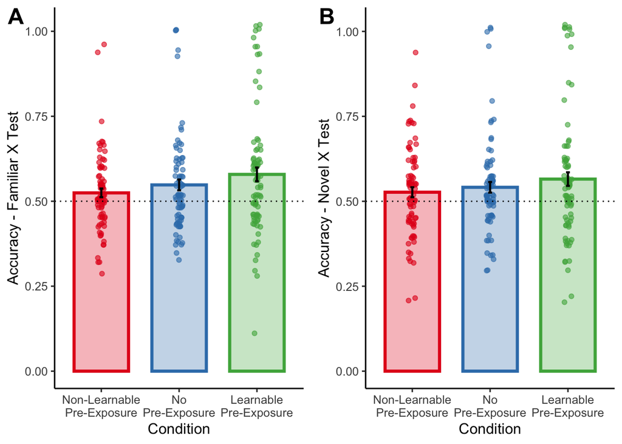

```r
#Familiar X Test
p1 <- ggplot(subset(test_type_exp,testType=="familiarX"&exp=="exp2"),aes(condition,accuracy,fill=condition, color=condition))+
  geom_bar(position=position_dodge(.9), stat="identity", size=1.2,alpha=0.3, width=0.7)+
  geom_jitter(data=subset(subj_testType,testType=="familiarX"&exp=="exp2"),aes(y=acc), width = 0.05, height=0.02, alpha=0.6,shape=21)+
  geom_errorbar(aes(ymin=accuracy-se,ymax=accuracy+se),color="black",position=position_dodge(.9),width=0.05, size=0.8)+
  theme_classic(base_size=12)+
  geom_hline(yintercept=0.5, linetype="dotted")+
  scale_x_discrete(name="Condition",
                   breaks=c("Non-Learnable Pre-Exposure","No Pre-Exposure","Learnable Pre-Exposure"),
                   labels=c("Non-Learnable\nPre-Exposure","No\nPre-Exposure","Learnable\nPre-Exposure"),
                   limits=c("Non-Learnable Pre-Exposure","No Pre-Exposure","Learnable Pre-Exposure"))+
  scale_fill_manual(values=c("#E41A1C","#377EB8","#4DAF4A"),limits=c("Non-Learnable Pre-Exposure","No Pre-Exposure","Learnable Pre-Exposure"))+
  scale_color_manual(values=c("#E41A1C","#377EB8","#4DAF4A"),limits=c("Non-Learnable Pre-Exposure","No Pre-Exposure","Learnable Pre-Exposure"))+
  theme(legend.position="none")+
  ylab("Accuracy - Familiar X Test")+
  xlab("Condition")

#Novel X
p2 <- ggplot(subset(test_type_exp,testType=="novelX"&exp=="exp2"),aes(condition,accuracy,fill=condition, color=condition))+
  geom_bar(position=position_dodge(.9), stat="identity", size=1.2,alpha=0.3, width=0.7)+
  geom_jitter(data=subset(subj_testType,testType=="novelX"&exp=="exp2"),aes(y=acc), width = 0.05, height=0.02, alpha=0.6,shape=21)+
  geom_errorbar(aes(ymin=accuracy-se,ymax=accuracy+se),color="black",position=position_dodge(.9),width=0.05, size=0.8)+
  theme_classic(base_size=12)+
  geom_hline(yintercept=0.5, linetype="dotted")+
  scale_x_discrete(name="Condition",
                   breaks=c("Non-Learnable Pre-Exposure","No Pre-Exposure","Learnable Pre-Exposure"),
                   labels=c("Non-Learnable\nPre-Exposure","No\nPre-Exposure","Learnable\nPre-Exposure"),
                   limits=c("Non-Learnable Pre-Exposure","No Pre-Exposure","Learnable Pre-Exposure"))+
  scale_fill_manual(values=c("#E41A1C","#377EB8","#4DAF4A"),limits=c("Non-Learnable Pre-Exposure","No Pre-Exposure","Learnable Pre-Exposure"))+
  scale_color_manual(values=c("#E41A1C","#377EB8","#4DAF4A"),limits=c("Non-Learnable Pre-Exposure","No Pre-Exposure","Learnable Pre-Exposure"))+
  theme(legend.position="none")+
  ylab("Accuracy - Novel X Test")+
  xlab("Condition")
plot_grid(p1,p2, labels=c("A","B"),label_size=18)
```

#### Overall Accuracy Table

```r
overall_exp %>%
  filter(exp=="exp2") %>%
  select(-c(se,accuracy_ci,d_prime_ci,c_bias_ci)) %>%
  formattable()
```

| exp | condition | N | accuracy | accuracy_lower_ci | accuracy_upper_ci | d_prime | d_prime_lower_ci | d_prime_upper_ci | c_bias | c_bias_lower_ci | c_bias_upper_ci |
| --- | --- | --- | --- | --- | --- | --- | --- | --- | --- | --- | --- |
| exp2 | Learnable Pre-Exposure | 83 | 0.5722301 | 0.5361125 | 0.6083476 | 0.5077750 | 0.25212450 | 0.7634256 | -0.1953715 | -0.2714524 | -0.1192905 |
| exp2 | No Pre-Exposure | 81 | 0.5445816 | 0.5165071 | 0.5726561 | 0.2917437 | 0.09294647 | 0.4905409 | -0.2817981 | -0.3880251 | -0.1755711 |
| exp2 | Non-Learnable Pre-Exposure | 79 | 0.5256681 | 0.5047038 | 0.5466323 | 0.1619213 | 0.03136162 | 0.2924810 | -0.3036137 | -0.3863990 | -0.2208284 |

#### Accuracy Table By Test Type

```r
test_type_exp %>%
  filter(exp=="exp2") %>%
  select(-c(se,accuracy_ci,d_prime_ci,c_bias_ci)) %>%
  formattable()
```

| exp | condition | testType | N | accuracy | accuracy_lower_ci | accuracy_upper_ci | d_prime | d_prime_lower_ci | d_prime_upper_ci | c_bias | c_bias_lower_ci | c_bias_upper_ci |
| --- | --- | --- | --- | --- | --- | --- | --- | --- | --- | --- | --- | --- |
| exp2 | Learnable Pre-Exposure | familiarX | 83 | 0.5789826 | 0.5386545 | 0.6193107 | 0.4870309 | 0.236126039 | 0.7379357 | -0.408382341 | -0.49734439 | -0.3194203 |
| exp2 | Learnable Pre-Exposure | novelX | 83 | 0.5653447 | 0.5256768 | 0.6050126 | 0.4027506 | 0.159998868 | 0.6455023 | 0.003715546 | -0.10535999 | 0.1127911 |
| exp2 | No Pre-Exposure | familiarX | 81 | 0.5480110 | 0.5164667 | 0.5795553 | 0.2995076 | 0.101032689 | 0.4979825 | -0.645538873 | -0.75491277 | -0.5361650 |
| exp2 | No Pre-Exposure | novelX | 81 | 0.5411523 | 0.5100279 | 0.5722766 | 0.2466637 | 0.058929824 | 0.4343976 | 0.086566193 | -0.07935325 | 0.2524856 |
| exp2 | Non-Learnable Pre-Exposure | familiarX | 79 | 0.5246132 | 0.4991932 | 0.5500332 | 0.1377382 | -0.017625810 | 0.2931023 | -0.573193547 | -0.67709443 | -0.4692927 |
| exp2 | Non-Learnable Pre-Exposure | novelX | 79 | 0.5267229 | 0.4975832 | 0.5558626 | 0.1657024 | -0.001404172 | 0.3328089 | -0.048268953 | -0.16192481 | 0.0653869 |

#### Correlation

##### Correlation between Familiar X and Novel X Trials: Learnable Pre-Exposure

```r
##Correlations between Familiar X and Novel X
c <- corr.test(subset(subj_accuracy_wide, condition=="Learnable Pre-Exposure" & exp=="exp2")[,c("novelX","familiarX")])
c
```

```
## Call:corr.test(x = subset(subj_accuracy_wide, condition == "Learnable Pre-Exposure" &
##     exp == "exp2")[, c("novelX", "familiarX")])
## Correlation matrix
##           novelX familiarX
## novelX      1.00      0.63
## familiarX   0.63      1.00
## Sample Size
## [1] 83
## Probability values (Entries above the diagonal are adjusted for multiple tests.)
##           novelX familiarX
## novelX         0         0
## familiarX      0         0
##
##  To see confidence intervals of the correlations, print with the short=FALSE option
```

```r
c$p
```

```
##                 novelX    familiarX
## novelX    0.000000e+00 2.081808e-10
## familiarX 2.081808e-10 0.000000e+00
```

##### Correlation between Familiar X and Novel X Trials: No Pre-Exposure

```r
c <- corr.test(subset(subj_accuracy_wide, condition=="No Pre-Exposure" & exp=="exp2")[,c("novelX","familiarX")])
c
```

```
## Call:corr.test(x = subset(subj_accuracy_wide, condition == "No Pre-Exposure" &
##     exp == "exp2")[, c("novelX", "familiarX")])
## Correlation matrix
##           novelX familiarX
## novelX      1.00      0.61
## familiarX   0.61      1.00
## Sample Size
## [1] 81
## Probability values (Entries above the diagonal are adjusted for multiple tests.)
##           novelX familiarX
## novelX         0         0
## familiarX      0         0
##
##  To see confidence intervals of the correlations, print with the short=FALSE option
```

```r
c$p
```

```
##                novelX   familiarX
## novelX    0.00000e+00 2.12128e-09
## familiarX 2.12128e-09 0.00000e+00
```

##### Correlation between Familiar X and Novel X Trials: Non-Learnable Pre-Exposure

```r
c <- corr.test(subset(subj_accuracy_wide, condition=="Non-Learnable Pre-Exposure" & exp=="exp2")[,c("novelX","familiarX")])
c
```

```
## Call:corr.test(x = subset(subj_accuracy_wide, condition == "Non-Learnable Pre-Exposure" &
##     exp == "exp2")[, c("novelX", "familiarX")])
## Correlation matrix
##           novelX familiarX
## novelX      1.00      0.18
## familiarX   0.18      1.00
## Sample Size
## [1] 79
## Probability values (Entries above the diagonal are adjusted for multiple tests.)
##           novelX familiarX
## novelX      0.00      0.12
## familiarX   0.12      0.00
##
##  To see confidence intervals of the correlations, print with the short=FALSE option
```

```r
c$p
```

```
##              novelX familiarX
## novelX    0.0000000 0.1179566
## familiarX 0.1179566 0.0000000
```

##### Interaction

```r
#interaction
subj_accuracy_wide$conditionC <- ifelse(subj_accuracy_wide$condition=="Learnable Pre-Exposure",0.5,
                           ifelse(subj_accuracy_wide$condition=="Non-Learnable Pre-Exposure",-0.5,
                                  ifelse(subj_accuracy_wide$condition=="No Pre-Exposure",0,NA)))
m <- lm(novelX~familiarX*conditionC, subset(subj_accuracy_wide,exp=="exp2"))
summary(m)
```

```
##
## Call:
## lm(formula = novelX ~ familiarX * conditionC, data = subset(subj_accuracy_wide,
##     exp == "exp2"))
##
## Residuals:
##      Min       1Q   Median       3Q      Max
## -0.45402 -0.07543  0.00254  0.07862  0.29724
##
## Coefficients:
##                      Estimate Std. Error t value Pr(>|t|)
## (Intercept)           0.27859    0.03362   8.287 8.36e-15 ***
## familiarX             0.47707    0.06007   7.941 7.81e-14 ***
## conditionC           -0.18070    0.08022  -2.253   0.0252 *
## familiarX:conditionC  0.35041    0.14285   2.453   0.0149 *
## ---
## Signif. codes:  0 '***' 0.001 '**' 0.01 '*' 0.05 '.' 0.1 ' ' 1
##
## Residual standard error: 0.1287 on 239 degrees of freedom
## Multiple R-squared:  0.3023, Adjusted R-squared:  0.2936
## F-statistic: 34.52 on 3 and 239 DF,  p-value: < 2.2e-16
```

#### Correlation Plot

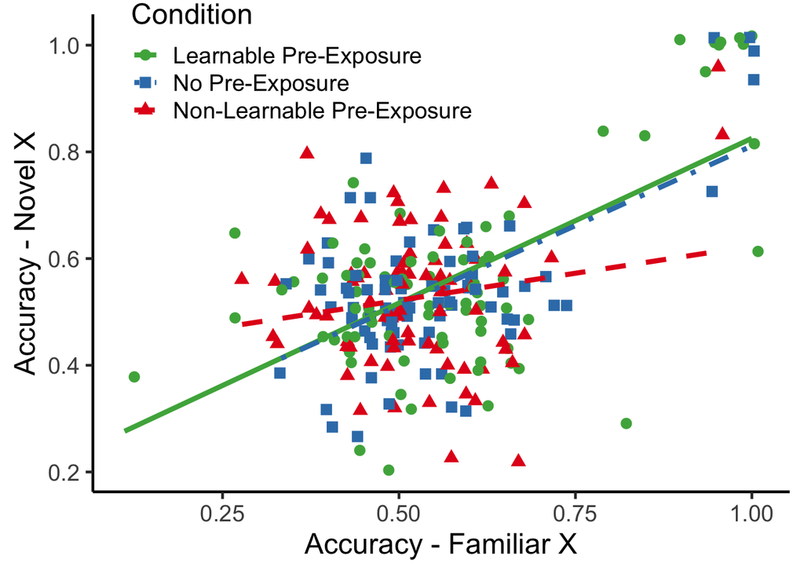

```r
ggplot(subset(subj_accuracy_wide,exp=="exp2"),aes(familiarX,novelX, color=condition,linetype=condition,shape=condition))+
  geom_jitter(width=0.02,height=0.02,size=3)+
  geom_smooth(method=lm,se =F,size=1.5)+
  scale_color_manual(name="Condition",values=c("#4DAF4A","#377EB8","#E41A1C"))+
  scale_linetype_manual(name="Condition",values=c(1,4,2))+
  scale_shape_manual(name="Condition",values=c(16,15,17))+
  ylab("Accuracy - Novel X")+
  xlab("Accuracy - Familiar X")+
  theme_classic(base_size=18)+
  theme(legend.position=c(0.3,0.9))
```

### Logistic Mixed-Effects Model

#### Overall

##### Final Converging Models

The final models with the maximal random effects structure that still allowed the model to converge, as reported in the manuscript.

Richter single-contrast approach.

```r
#recode condition
d$conditionC <- ifelse(d$condition=="Learnable Pre-Exposure",0.5,
                    ifelse(d$condition=="Non-Learnable Pre-Exposure",-0.5,
                           ifelse(d$condition=="No Pre-Exposure",0,NA)))
d$conditionOrthContrast2 <- ifelse(d$condition=="Learnable Pre-Exposure",-1/3,
                                ifelse(d$condition=="Non-Learnable Pre-Exposure",-1/3,
                                       ifelse(d$condition=="No Pre-Exposure",2/3,NA)))

#overall analysis (Richter single-contrast apporach)
m <- glmer(isRight~conditionC+(1|participantCode),data=subset(d,exp=="exp2"),family=binomial,glmerControl(optimizer="bobyqa"))
summary(m)
```

```
## Generalized linear mixed model fit by maximum likelihood (Laplace
##   Approximation) [glmerMod]
##  Family: binomial  ( logit )
## Formula: isRight ~ conditionC + (1 | participantCode)
##    Data: subset(d, exp == "exp2")
## Control: glmerControl(optimizer = "bobyqa")
##
##      AIC      BIC   logLik deviance df.resid
##  11872.8  11894.0  -5933.4  11866.8     8743
##
## Scaled residuals:
##     Min      1Q  Median      3Q     Max
## -2.1798 -1.0343  0.4833  0.9310  1.3423
##
## Random effects:
##  Groups          Name        Variance Std.Dev.
##  participantCode (Intercept) 0.2357   0.4855
## Number of obs: 8746, groups:  participantCode, 243
##
## Fixed effects:
##             Estimate Std. Error z value Pr(>|z|)
## (Intercept)   0.2104     0.0383   5.493 3.94e-08 ***
## conditionC    0.2165     0.0937   2.310   0.0209 *
## ---
## Signif. codes:  0 '***' 0.001 '**' 0.01 '*' 0.05 '.' 0.1 ' ' 1
##
## Correlation of Fixed Effects:
##            (Intr)
## conditionC -0.008
```

```r
confint(m, method="Wald")
```

```
##                  2.5 %    97.5 %
## .sig01              NA        NA
## (Intercept) 0.13533554 0.2854744
## conditionC  0.03282819 0.4001370
```

Abelson & Prentice approach.

```r
##check same analysis with Abelson & Prentice approach
m <- glmer(isRight~conditionC+conditionOrthContrast2+(1|participantCode),data=subset(d,exp=="exp2"),family=binomial,glmerControl(optimizer="bobyqa"))
summary(m)
```

```
## Generalized linear mixed model fit by maximum likelihood (Laplace
##   Approximation) [glmerMod]
##  Family: binomial  ( logit )
## Formula:
## isRight ~ conditionC + conditionOrthContrast2 + (1 | participantCode)
##    Data: subset(d, exp == "exp2")
## Control: glmerControl(optimizer = "bobyqa")
##
##      AIC      BIC   logLik deviance df.resid
##  11874.7  11903.0  -5933.3  11866.7     8742
##
## Scaled residuals:
##     Min      1Q  Median      3Q     Max
## -2.1830 -1.0320  0.4826  0.9331  1.3406
##
## Random effects:
##  Groups          Name        Variance Std.Dev.
##  participantCode (Intercept) 0.2356   0.4854
## Number of obs: 8746, groups:  participantCode, 243
##
## Fixed effects:
##                        Estimate Std. Error z value Pr(>|z|)
## (Intercept)             0.21042    0.03830   5.494 3.92e-08 ***
## conditionC              0.21628    0.09372   2.308    0.021 *
## conditionOrthContrast2 -0.02106    0.08098  -0.260    0.795
## ---
## Signif. codes:  0 '***' 0.001 '**' 0.01 '*' 0.05 '.' 0.1 ' ' 1
##
## Correlation of Fixed Effects:
##             (Intr) cndtnC
## conditionC  -0.008
## cndtnOrthC2 -0.002  0.008
```

```r
confint(m, method="Wald")
```

```
##                              2.5 %    97.5 %
## .sig01                          NA        NA
## (Intercept)             0.13535407 0.2854761
## conditionC              0.03259514 0.3999630
## conditionOrthContrast2 -0.17978510 0.1376648
```

##### Maximal Random Effects Model

Note that these model does not converge (singular fit), thus the parameter estimates should be interpreted with caution.

Richter single-contrast approach.

```r
#overall analysis (Richter single-contrast apporach)
m <- glmer(isRight~conditionC+(1|participantCode)+(1+conditionC|stimulus),data=subset(d,exp=="exp2"),family=binomial,glmerControl(optimizer="bobyqa")) #convergence warning
```

```
## boundary (singular) fit: see ?isSingular
```

```r
summary(m)
```

```
## Generalized linear mixed model fit by maximum likelihood (Laplace
##   Approximation) [glmerMod]
##  Family: binomial  ( logit )
## Formula: isRight ~ conditionC + (1 | participantCode) + (1 + conditionC |
##     stimulus)
##    Data: subset(d, exp == "exp2")
## Control: glmerControl(optimizer = "bobyqa")
##
##      AIC      BIC   logLik deviance df.resid
##  11878.8  11921.2  -5933.4  11866.8     8740
##
## Scaled residuals:
##     Min      1Q  Median      3Q     Max
## -2.1798 -1.0343  0.4833  0.9310  1.3423
##
## Random effects:
##  Groups          Name        Variance  Std.Dev.  Corr
##  participantCode (Intercept) 2.357e-01 4.855e-01
##  stimulus        (Intercept) 7.043e-14 2.654e-07
##                  conditionC  5.117e-12 2.262e-06 1.00
## Number of obs: 8746, groups:  participantCode, 243; stimulus, 36
##
## Fixed effects:
##             Estimate Std. Error z value Pr(>|z|)
## (Intercept)  0.21041    0.03830   5.493 3.95e-08 ***
## conditionC   0.21648    0.09372   2.310   0.0209 *
## ---
## Signif. codes:  0 '***' 0.001 '**' 0.01 '*' 0.05 '.' 0.1 ' ' 1
##
## Correlation of Fixed Effects:
##            (Intr)
## conditionC -0.008
## convergence code: 0
## boundary (singular) fit: see ?isSingular
```

```r
confint(m, method="Wald")[5:6,]
```

```
##                 2.5 %    97.5 %
## (Intercept) 0.1353330 0.2854778
## conditionC  0.0327907 0.4001751
```

Abelson & Prentice approach.

```r
##check same analysis with Abelson & Prentice approach
m=glmer(isRight~conditionC+conditionOrthContrast2+(1|participantCode)+(1+conditionC+conditionOrthContrast2|stimulus),data=subset(d,exp=="exp2"),family=binomial,glmerControl(optimizer="bobyqa")) #convergence warning
```

```
## boundary (singular) fit: see ?isSingular
```

```r
summary(m)
```

```
## Generalized linear mixed model fit by maximum likelihood (Laplace
##   Approximation) [glmerMod]
##  Family: binomial  ( logit )
## Formula:
## isRight ~ conditionC + conditionOrthContrast2 + (1 | participantCode) +
##     (1 + conditionC + conditionOrthContrast2 | stimulus)
##    Data: subset(d, exp == "exp2")
## Control: glmerControl(optimizer = "bobyqa")
##
##      AIC      BIC   logLik deviance df.resid
##  11886.5  11957.3  -5933.3  11866.5     8736
##
## Scaled residuals:
##     Min      1Q  Median      3Q     Max
## -2.1902 -1.0241  0.4887  0.9259  1.3662
##
## Random effects:
##  Groups          Name                   Variance Std.Dev. Corr
##  participantCode (Intercept)            0.236011 0.48581
##  stimulus        (Intercept)            0.000000 0.00000
##                  conditionC             0.006386 0.07991    NaN
##                  conditionOrthContrast2 0.003532 0.05943    NaN -1.00
## Number of obs: 8746, groups:  participantCode, 243; stimulus, 36
##
## Fixed effects:
##                        Estimate Std. Error z value Pr(>|z|)
## (Intercept)             0.21054    0.03832   5.494 3.93e-08 ***
## conditionC              0.21654    0.09472   2.286   0.0222 *
## conditionOrthContrast2 -0.02112    0.08164  -0.259   0.7959
## ---
## Signif. codes:  0 '***' 0.001 '**' 0.01 '*' 0.05 '.' 0.1 ' ' 1
##
## Correlation of Fixed Effects:
##             (Intr) cndtnC
## conditionC  -0.008
## cndtnOrthC2 -0.002 -0.009
## convergence code: 0
## boundary (singular) fit: see ?isSingular
```

```r
confint(m, method="Wald")[8:10,]
```

```
##                              2.5 %    97.5 %
## (Intercept)             0.13543373 0.2856546
## conditionC              0.03090042 0.4021836
## conditionOrthContrast2 -0.18113716 0.1388980
```

#### Pairwise condition comparisons

##### Learnable vs. Non-Learnable Pre-Exposure

###### Final Converging Model

The final model with the maximal random effects structure that still allowed the model to converge.

```r
m <- glmer(isRight~conditionC+(1|participantCode),data=subset(d,exp=="exp2"&conditionC!=0),family=binomial,glmerControl(optimizer="bobyqa"))
summary(m)
```

```
## Generalized linear mixed model fit by maximum likelihood (Laplace
##   Approximation) [glmerMod]
##  Family: binomial  ( logit )
## Formula: isRight ~ conditionC + (1 | participantCode)
##    Data: subset(d, exp == "exp2" & conditionC != 0)
## Control: glmerControl(optimizer = "bobyqa")
##
##      AIC      BIC   logLik deviance df.resid
##   7895.9   7915.9  -3945.0   7889.9     5827
##
## Scaled residuals:
##     Min      1Q  Median      3Q     Max
## -2.2363 -1.0167  0.4943  0.9153  1.3574
##
## Random effects:
##  Groups          Name        Variance Std.Dev.
##  participantCode (Intercept) 0.2563   0.5063
## Number of obs: 5830, groups:  participantCode, 162
##
## Fixed effects:
##             Estimate Std. Error z value Pr(>|z|)
## (Intercept)  0.21900    0.04832   4.533 5.82e-06 ***
## conditionC   0.21853    0.09651   2.264   0.0236 *
## ---
## Signif. codes:  0 '***' 0.001 '**' 0.01 '*' 0.05 '.' 0.1 ' ' 1
##
## Correlation of Fixed Effects:
##            (Intr)
## conditionC -0.010
```

```r
confint(m, method="Wald")[2:3,]
```

```
##                  2.5 %    97.5 %
## (Intercept) 0.12430384 0.3136995
## conditionC  0.02937304 0.4076837
```

###### Maximal Random Effects Model

Note that this model does not converge (singular fit), thus the parameter estimates should be interpreted with caution.

```r
#Learnable vs. Non-Learnable
m <- glmer(isRight~conditionC+(1|participantCode)+(1+conditionC|stimulus),data=subset(d,exp=="exp2"&conditionC!=0),family=binomial,glmerControl(optimizer="bobyqa"))
```

```
## boundary (singular) fit: see ?isSingular
```

```r
summary(m)
```

```
## Generalized linear mixed model fit by maximum likelihood (Laplace
##   Approximation) [glmerMod]
##  Family: binomial  ( logit )
## Formula: isRight ~ conditionC + (1 | participantCode) + (1 + conditionC |
##     stimulus)
##    Data: subset(d, exp == "exp2" & conditionC != 0)
## Control: glmerControl(optimizer = "bobyqa")
##
##      AIC      BIC   logLik deviance df.resid
##   7901.8   7941.8  -3944.9   7889.8     5824
##
## Scaled residuals:
##     Min      1Q  Median      3Q     Max
## -2.2458 -1.0167  0.4940  0.9184  1.3877
##
## Random effects:
##  Groups          Name        Variance Std.Dev. Corr
##  participantCode (Intercept) 0.256944 0.50690
##  stimulus        (Intercept) 0.001265 0.03556
##                  conditionC  0.005020 0.07086  1.00
## Number of obs: 5830, groups:  participantCode, 162; stimulus, 36
##
## Fixed effects:
##             Estimate Std. Error z value Pr(>|z|)
## (Intercept)  0.21921    0.04872   4.499 6.83e-06 ***
## conditionC   0.21892    0.09732   2.250   0.0245 *
## ---
## Signif. codes:  0 '***' 0.001 '**' 0.01 '*' 0.05 '.' 0.1 ' ' 1
##
## Correlation of Fixed Effects:
##            (Intr)
## conditionC 0.005
## convergence code: 0
## boundary (singular) fit: see ?isSingular
```

```r
confint(m, method="Wald")[5:6,]
```

```
##                  2.5 %    97.5 %
## (Intercept) 0.12371158 0.3147080
## conditionC  0.02818059 0.4096622
```

##### No Pre-Exposure vs. Non-Learnable Pre-Exposure

###### Final Converging Model

The final model with the maximal random effects structure that still allowed the model to converge.

```r
#Non-Learnable vs. No Pre-Exposure
d$conditionNonLearnableNoPreExp <- ifelse(d$conditionC==0.5,1.5,
                                    ifelse(d$conditionC==0,0.5,d$conditionC))
m <- glmer(isRight~conditionNonLearnableNoPreExp+(1|participantCode),data=subset(d,exp=="exp2"&conditionNonLearnableNoPreExp!=1.5),family=binomial,glmerControl(optimizer="bobyqa"))
summary(m)
```

```
## Generalized linear mixed model fit by maximum likelihood (Laplace
##   Approximation) [glmerMod]
##  Family: binomial  ( logit )
## Formula: isRight ~ conditionNonLearnableNoPreExp + (1 | participantCode)
##    Data: subset(d, exp == "exp2" & conditionNonLearnableNoPreExp != 1.5)
## Control: glmerControl(optimizer = "bobyqa")
##
##      AIC      BIC   logLik deviance df.resid
##   7925.0   7945.0  -3959.5   7919.0     5757
##
## Scaled residuals:
##     Min      1Q  Median      3Q     Max
## -1.6833 -1.0280  0.6637  0.9472  1.1175
##
## Random effects:
##  Groups          Name        Variance Std.Dev.
##  participantCode (Intercept) 0.1019   0.3192
## Number of obs: 5760, groups:  participantCode, 160
##
## Fixed effects:
##                               Estimate Std. Error z value Pr(>|z|)
## (Intercept)                    0.14609    0.03681   3.969 7.22e-05 ***
## conditionNonLearnableNoPreExp  0.08050    0.07357   1.094    0.274
## ---
## Signif. codes:  0 '***' 0.001 '**' 0.01 '*' 0.05 '.' 0.1 ' ' 1
##
## Correlation of Fixed Effects:
##             (Intr)
## cndtnNnLNPE -0.008
```

```r
confint(m, method="Wald")[2:3,]
```

```
##                                     2.5 %    97.5 %
## (Intercept)                    0.07394511 0.2182280
## conditionNonLearnableNoPreExp -0.06368933 0.2246826
```

###### Maximal Random Effects Model

Note that this model does not converge (singular fit), thus the parameter estimates should be interpreted with caution.

```r
m <- glmer(isRight~conditionNonLearnableNoPreExp+(1|participantCode)+(1+conditionNonLearnableNoPreExp|stimulus),data=subset(d,exp=="exp2"&conditionNonLearnableNoPreExp!=1.5),family=binomial,glmerControl(optimizer="bobyqa"))
```

```
## boundary (singular) fit: see ?isSingular
```

```r
summary(m)
```

```
## Generalized linear mixed model fit by maximum likelihood (Laplace
##   Approximation) [glmerMod]
##  Family: binomial  ( logit )
## Formula:
## isRight ~ conditionNonLearnableNoPreExp + (1 | participantCode) +
##     (1 + conditionNonLearnableNoPreExp | stimulus)
##    Data: subset(d, exp == "exp2" & conditionNonLearnableNoPreExp != 1.5)
## Control: glmerControl(optimizer = "bobyqa")
##
##      AIC      BIC   logLik deviance df.resid
##   7931.0   7971.0  -3959.5   7919.0     5754
##
## Scaled residuals:
##     Min      1Q  Median      3Q     Max
## -1.6832 -1.0280  0.6637  0.9472  1.1175
##
## Random effects:
##  Groups          Name                          Variance  Std.Dev.  Corr
##  participantCode (Intercept)                   1.019e-01 3.192e-01
##  stimulus        (Intercept)                   0.000e+00 0.000e+00
##                  conditionNonLearnableNoPreExp 1.884e-13 4.340e-07  NaN
## Number of obs: 5760, groups:  participantCode, 160; stimulus, 36
##
## Fixed effects:
##                               Estimate Std. Error z value Pr(>|z|)
## (Intercept)                    0.14609    0.03681   3.969 7.22e-05 ***
## conditionNonLearnableNoPreExp  0.08050    0.07357   1.094    0.274
## ---
## Signif. codes:  0 '***' 0.001 '**' 0.01 '*' 0.05 '.' 0.1 ' ' 1
##
## Correlation of Fixed Effects:
##             (Intr)
## cndtnNnLNPE -0.008
## convergence code: 0
## boundary (singular) fit: see ?isSingular
```

```r
confint(m, method="Wald")[5:6,]
```

```
##                                     2.5 %    97.5 %
## (Intercept)                    0.07394446 0.2182281
## conditionNonLearnableNoPreExp -0.06369568 0.2246870
```

##### Learnable vs. No Pre-Exposure

###### Final Converging Model

The final model with the maximal random effects structure that still allowed the model to converge.

```r
#Learnable vs. No Pre-Exposure
d$conditionLearnableNoPreExp <- ifelse(d$conditionC==-0.5,-1.5,
                                    ifelse(d$conditionC==0,-0.5,d$conditionC))
m <- glmer(isRight~conditionLearnableNoPreExp+(1|participantCode)+(0+conditionLearnableNoPreExp|stimulus),data=subset(d,exp=="exp2"&conditionLearnableNoPreExp!=-1.5),family=binomial,glmerControl(optimizer="bobyqa"))
summary(m)
```

```
## Generalized linear mixed model fit by maximum likelihood (Laplace
##   Approximation) [glmerMod]
##  Family: binomial  ( logit )
## Formula: isRight ~ conditionLearnableNoPreExp + (1 | participantCode) +
##     (0 + conditionLearnableNoPreExp | stimulus)
##    Data: subset(d, exp == "exp2" & conditionLearnableNoPreExp != -1.5)
## Control: glmerControl(optimizer = "bobyqa")
##
##      AIC      BIC   logLik deviance df.resid
##   7912.0   7938.7  -3952.0   7904.0     5898
##
## Scaled residuals:
##     Min      1Q  Median      3Q     Max
## -2.5150 -1.0227  0.4116  0.9217  1.4431
##
## Random effects:
##  Groups          Name                       Variance Std.Dev.
##  participantCode (Intercept)                0.380740 0.61704
##  stimulus        conditionLearnableNoPreExp 0.007125 0.08441
## Number of obs: 5902, groups:  participantCode, 164; stimulus, 36
##
## Fixed effects:
##                            Estimate Std. Error z value Pr(>|z|)
## (Intercept)                 0.27389    0.05571   4.916 8.82e-07 ***
## conditionLearnableNoPreExp  0.13751    0.11189   1.229    0.219
## ---
## Signif. codes:  0 '***' 0.001 '**' 0.01 '*' 0.05 '.' 0.1 ' ' 1
##
## Correlation of Fixed Effects:
##             (Intr)
## cndtnLrnNPE -0.003
```

```r
confint(m, method="Wald")[3:4,]
```

```
##                                  2.5 %    97.5 %
## (Intercept)                 0.16470200 0.3830818
## conditionLearnableNoPreExp -0.08180022 0.3568143
```

###### Maximal Random Effects Model

Note that this model does not converge (singular fit), thus the parameter estimates should be interpreted with caution.

```r
#Learnable vs. No Pre-Exposure
m <- glmer(isRight~conditionLearnableNoPreExp+(1|participantCode)+(1+conditionLearnableNoPreExp|stimulus),data=subset(d,exp=="exp2"&conditionLearnableNoPreExp!=-1.5),family=binomial,glmerControl(optimizer="bobyqa"))
```

```
## boundary (singular) fit: see ?isSingular
```

```r
summary(m)
```

```
## Generalized linear mixed model fit by maximum likelihood (Laplace
##   Approximation) [glmerMod]
##  Family: binomial  ( logit )
## Formula: isRight ~ conditionLearnableNoPreExp + (1 | participantCode) +
##     (1 + conditionLearnableNoPreExp | stimulus)
##    Data: subset(d, exp == "exp2" & conditionLearnableNoPreExp != -1.5)
## Control: glmerControl(optimizer = "bobyqa")
##
##      AIC      BIC   logLik deviance df.resid
##   7915.6   7955.7  -3951.8   7903.6     5896
##
## Scaled residuals:
##     Min      1Q  Median      3Q     Max
## -2.5284 -1.0206  0.4115  0.9242  1.4803
##
## Random effects:
##  Groups          Name                       Variance  Std.Dev. Corr
##  participantCode (Intercept)                0.3815973 0.61774
##  stimulus        (Intercept)                0.0008796 0.02966
##                  conditionLearnableNoPreExp 0.0151500 0.12309  1.00
## Number of obs: 5902, groups:  participantCode, 164; stimulus, 36
##
## Fixed effects:
##                            Estimate Std. Error z value Pr(>|z|)
## (Intercept)                 0.27415    0.05598   4.897 9.72e-07 ***
## conditionLearnableNoPreExp  0.13800    0.11299   1.221    0.222
## ---
## Signif. codes:  0 '***' 0.001 '**' 0.01 '*' 0.05 '.' 0.1 ' ' 1
##
## Correlation of Fixed Effects:
##             (Intr)
## cndtnLrnNPE 0.014
## convergence code: 0
## boundary (singular) fit: see ?isSingular
```

```r
confint(m, method="Wald")[5:6,]
```

```
##                                  2.5 %    97.5 %
## (Intercept)                 0.16443145 0.3838737
## conditionLearnableNoPreExp -0.08345495 0.3594534
```

##### Testing against chance: Learnable Pre-Exposure

###### Final Converging Model

The final model with the maximal random effects structure that still allowed the model to converge.

```r
#Learnable
m <- glmer(isRight~1+(1|participantCode)+(1|stimulus),data=subset(d,exp=="exp2"&conditionC==0.5),family=binomial,glmerControl(optimizer="bobyqa"))
summary(m)
```

```
## Generalized linear mixed model fit by maximum likelihood (Laplace
##   Approximation) [glmerMod]
##  Family: binomial  ( logit )
## Formula: isRight ~ 1 + (1 | participantCode) + (1 | stimulus)
##    Data: subset(d, exp == "exp2" & conditionC == 0.5)
## Control: glmerControl(optimizer = "bobyqa")
##
##      AIC      BIC   logLik deviance df.resid
##   3924.0   3942.1  -1959.0   3918.0     2983
##
## Scaled residuals:
##     Min      1Q  Median      3Q     Max
## -2.8814 -1.0176  0.3731  0.9146  1.5554
##
## Random effects:
##  Groups          Name        Variance Std.Dev.
##  participantCode (Intercept) 0.600946 0.77521
##  stimulus        (Intercept) 0.007036 0.08388
## Number of obs: 2986, groups:  participantCode, 83; stimulus, 36
##
## Fixed effects:
##             Estimate Std. Error z value Pr(>|z|)
## (Intercept)  0.36246    0.09558   3.792 0.000149 ***
## ---
## Signif. codes:  0 '***' 0.001 '**' 0.01 '*' 0.05 '.' 0.1 ' ' 1
```

```r
confint(m, method="Wald")
```

```
##                 2.5 %    97.5 %
## .sig01             NA        NA
## .sig02             NA        NA
## (Intercept) 0.1751252 0.5497959
```